# Deep_learning4

## Problema de clasificación

```python
# Importaciones necesarias
import seaborn as sns
import pandas as pd
import matplotlib.pyplot as plt

# Cargamos los datos
banknotes = pd.read_csv('https://cursopypagina.github.io/CursoPy/banknotes.csv')
```

```python
# Exporamos la informacion sobre nuestros datos
banknotes.head()
```

|  | variace | skewness | curtosis | entropy | class |
| --- | --- | --- | --- | --- | --- |
| 0 | 3.62160 | 8.6661 | -2.8073 | -0.44699 | 0 |
| 1 | 4.54590 | 8.1674 | -2.4586 | -1.46210 | 0 |
| 2 | 3.86600 | -2.6383 | 1.9242 | 0.10645 | 0 |
| 3 | 3.45660 | 9.5228 | -4.0112 | -3.59440 | 0 |
| 4 | 0.32924 | -4.4552 | 4.5718 | -0.98880 | 0 |

```python
banknotes.shape
```

```
(1372, 5)
```

`banknotes` es una base de datos sobre la autentificación de billetes de dólares mediante 4 características, las cuales fueron calculadas realizando operaciones matemáticas sobre imágenes de los billetes de dólares. La clasificación de si el billete es verdadero o no está en la columna `class` que solo tiene ceros y unos

Indaguemos graficamente sobre nuestros datos

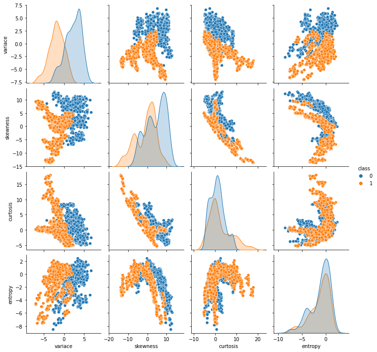

```python
sns.pairplot(banknotes, hue='class')
plt.show()
```

```python
banknotes['class'].value_counts()
```

```
0    762
1    610
Name: class, dtype: int64
```

de donde hay características para las que las clases se extienden notablemente, esto nos da una intuición de que nuestras clases son fácilmente separables.

Ahora bien, dado que tenemos 4 características, entonces nuestra capa de entrada tendrá 4 neuronas, no tendremos capas ocultas y la capa de salida tendrá sólo una neurona en la cual implementaremos la función de activación sigmoide, donde para valores $<0.5$ asignaremos la etiqueta 0 y para valores $\geq5$ le asignaremos la etiqueta 1. Dichos valores lo interpretaremos como probabilidades, donde 1 nos dirá que el billete es falso.

Procedemos a crear nuestro modelo

```python
# Realizamos las importaciones necesarias
from keras.models import Sequential
from keras.layers import Dense
import numpy as np

# Fijamos una semilla
np.random.seed(123)

# Instanciamos el modelo
model = Sequential()

# Capa de entrada de 4 neuronas y capa de salida de una neurona
model.add(Dense(1, input_shape=(4,), activation='sigmoid'))

# Copilacion del modelo.
# El optimizador sera: descenso del gradiente estocastico
model.compile(optimizer='sgd', loss='binary_crossentropy', metrics=['accuracy'])

# Vemos un resumen sobre nuestro modelo
model.summary()
```

```
Model: "sequential"
_________________________________________________________________
 Layer (type)                Output Shape              Param #
=================================================================
 dense (Dense)               (None, 1)                 5

=================================================================
Total params: 5
Trainable params: 5
Non-trainable params: 0
_________________________________________________________________
```

Convertimos nuestros datos a un NumPy array:

```python
banknotes = np.array(banknotes)
```

Realizamos la división de los datos

```python
from sklearn.model_selection import train_test_split
# Puntos
X =  banknotes[:, 0:4]
# Etiquetas
y = banknotes[:, 4]

# Division de los datos
X_train, X_test, y_train, y_test = train_test_split(
                                        X,
                                        y,
                                        train_size   = 0.25,
                                        random_state = 123)
```

después, ajustamos el modelo y vemos la evaluación del mismo

```python
# Ajustamos el modelo
model.fit(X_train, y_train, epochs=20, verbose=0)

# Evaluacion del modelo
scores = model.evaluate(X_train, y_train)
print('%s: %.4f%%' % (model.metrics_names[1], scores[1] * 100))
```

```
accuracy: 94.4606%
```

Procedemos a realizar la predicción y comparamos dichas predicciones con los valores reales

```python
# Realizamos las predicciones
predicciones = model.predict(X_test).round()

# Creamos un dataframe vacio
dict1 = {'Predicción': [0 for i in range(X_test.shape[0])],
         'Valor real': [0 for i in range(X_test.shape[0])]}
df = pd.DataFrame(dict1)

# Llenamos el dataframe
for i in range(X_test.shape[0]):
    df.iloc[i][0] = predicciones[i][0]
    df.iloc[i][1] = y_test[i]

# Comparamos
df
```

|  | Predicción | Valor real |
| --- | --- | --- |
| 0 | 0 | 0 |
| 1 | 0 | 0 |
| 2 | 0 | 0 |
| 3 | 0 | 0 |
| 4 | 1 | 1 |
| ... | ... | ... |
| 1024 | 0 | 0 |
| 1025 | 1 | 1 |
| 1026 | 0 | 0 |
| 1027 | 1 | 1 |
| 1028 | 0 | 0 |

1029 rows × 2 columns

```python
count = 0
for i in range(1029):
    if df.iloc[i][0] != df.iloc[i][1]:
        count += 1
count
```

```
52
```

Veamos algunos gráficos:

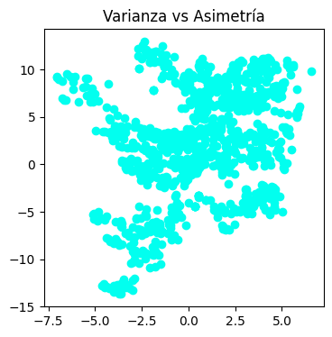

```python
# Datos de prueba:
plt.figure(figsize=(4,4))
import matplotlib.pyplot as plt

# Graficamos
for i in range(X_test.shape[0]):
    plt.plot(X_test[i][0], X_test[i][1], marker="o", color="#02FFEF")
plt.title('Varianza vs Asimetría')
plt.show()
```

Veamos el mismo gráfico con la separación hecha por nuestra red neuronal

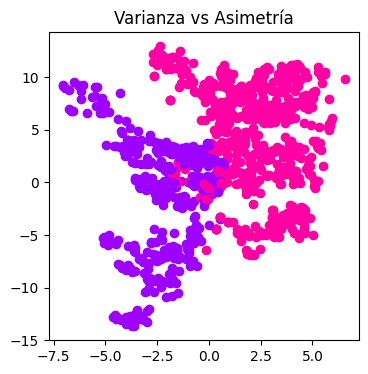

```python
plt.figure(figsize=(4,4))
# Graficamos
for i in range(X_test.shape[0]):
    # si la etiqueta es 1 (billetes falsos), el color es morado
    if predicciones[i][0] == 1:
        plt.plot(X_test[i][0], X_test[i][1], marker="o", color="#9D02FF")
    # si la etiqueta es 0 (billetes verdaderos), el color es maguenta
    else:
        plt.plot(X_test[i][0], X_test[i][1], marker="o", color="#FF02A3")
plt.title('Varianza vs Asimetría')
plt.show()
```

Veamos ahora el gráfico original

```python
banknotes = pd.read_csv('https://cursopypagina.github.io/CursoPy/banknotes.csv')
banknotes.columns
```

```
Index(['variace', 'skewness', 'curtosis', 'entropy', 'class'], dtype='object')
```

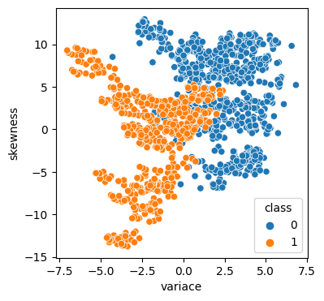

```python
plt.figure(figsize=(4,4))
sns.scatterplot(data=banknotes, x="variace", y="skewness", hue='class')
plt.show()
```